# SI 370 - Homework #1: Data Manipulation and Preliminary Analyses

## Background

This homework assignment focuses on the exploration and analysis of historical data from the Olympic games. The description of the data includes the following:

> This is a historical dataset on the modern Olympic Games, including all the Games from Athens 1896 to Rio 2016. I scraped this data from www.sports-reference.com in May 2018.

Your main task in this assignment is to explore the data *using the data manipulation and analysis methods we covered in class* as well as those in the assigned readings. You may need to consult pandas documentation, Stack Overflow, or other online resources.

**You should also feel free to ask questions on Slack!**

A total of 30 points is available in this homework assignment.

Each of Questions 1-5 are worth 5 points each. Points will be allocated according to the following rubric:

- 5 points: Question is correctly and completely answered. Answer consists of well-written code that conforms to [PEP 8](https://www.python.org/dev/peps/pep-0008/) guidelines and is accompanied by a written interpretation in a Markdown block. Written interpretation does not contain spelling, grammar or stylistic errors (see https://faculty.washington.edu/heagerty/Courses/b572/public/StrunkWhite.pdf for a detailed specifications).
- 4 points: Answer is mostly complete and correct; two or fewer noticeable omissions or errors. Minor stylistic flaws, either in code or in written interpretation.
- 3 points: Answer has significant omissions or errors; Noticeable departure from PEP-8 guildelines and/or moderate spelling, grammar, or style issues in written interpretations.
- 2 points: Question is perfunctorily attempted. Substantial parts are missing or incorrect.
- 0 points: Question not attempted.

A bonus question worth up to 5 points is also available.

```python
#PEP 8 all right things to do in python code: style guide
```

## First, read about the data (athlete_events.csv) from:

- https://www.kaggle.com/heesoo37/120-years-of-olympic-history-athletes-and-results

Note: The data file is available via https://bit.ly/2lUIi5P, which you should use in your work below.

## Answer the questions below.

For each question, you should

1. Write code using Python and pandas that can help you answer the following questions, and
2. Explain your answers in plain English. You should use complete sentences that would be understood by an educated professional who is not necessarily a data scientist (like a product manager). (explain what you did and then what you found)

### Name: Samantha Cohen (samcoh)

### Q1 Load and describe the dataset. (5pt)

- How many number rows and columns are there in the data frame?
- Provide summary statistics (i.e. use the .describe() function) for the numeric variables (other than ID) from the athlete_events.csv file.

#### 1) import pandas into jupyter notebook file

```python
import pandas as pd
```

#### 2) Load the csv file as a pandas DataFrame called olympic_games

```python
# loading the dataset as a pandas dataframe
olympic_games = pd.read_csv('https://bit.ly/2lUIi5P')
```

##### Explanation:

I used the read_csv method in pandas to read in the data from the link provided: https://bit.ly/2lUIi5P .

#### 2) How many number of rows and columns are there in the data frame?

```python
olympic_games =olympic_games.set_index('ID') #make ID the index

#use shape attribute on olympic_games and save it to the variable tuple_rows_columns
tuple_rows_columns =olympic_games.shape #tuple_rows_columns: is a tuple where the first element

num_rows = tuple_rows_columns[0] #num_rows is the number of rows

num_columns = tuple_rows_columns[1] #num_columns is the number of columns

"There are {} rows and {} columns".format(num_rows, num_columns)
```

```
'There are 271116 rows and 14 columns'
```

##### Explanation:

First, I made the column ID the index in the DataFrame olympic_games by using the method set_index. Afterwards, I found the number of rows and columns in the Dataframe olympic_games by using the shape attribute. The shape attribute returns a tuple where the first element is the number of rows and the second is the number of columns. I found that there are 271116 rows and 14 columns in the dataframe. If ID was still a column there would be 15 columns, but I made ID the index so there are now 14 columns in the DataFrame olympic_games.

#### 3) Provide summary statistics (i.e. use the .describe() function) for the numeric variables (other than ID) from the athlete_events.csv file

```python
olympic_games_summary_stats = olympic_games.describe()

olympic_games_summary_stats
```

|  | Age | Height | Weight | Year |
| --- | --- | --- | --- | --- |
| count | 261642.000000 | 210945.000000 | 208241.000000 | 271116.000000 |
| mean | 25.556898 | 175.338970 | 70.702393 | 1978.378480 |
| std | 6.393561 | 10.518462 | 14.348020 | 29.877632 |
| min | 10.000000 | 127.000000 | 25.000000 | 1896.000000 |
| 25% | 21.000000 | 168.000000 | 60.000000 | 1960.000000 |
| 50% | 24.000000 | 175.000000 | 70.000000 | 1988.000000 |
| 75% | 28.000000 | 183.000000 | 79.000000 | 2002.000000 |
| max | 97.000000 | 226.000000 | 214.000000 | 2016.000000 |

```python
#examining the max age
olympic_games[olympic_games["Age"] == 97.000000]
```

| ID | Name | Sex | Age | Height | Weight | Team | NOC | Games | Year | Season | City | Sport | Event | Medal |
| --- | --- | --- | --- | --- | --- | --- | --- | --- | --- | --- | --- | --- | --- | --- |
| 128719 | John Quincy Adams Ward | M | 97.0 | NaN | NaN | United States | USA | 1928 Summer | 1928 | Summer | Amsterdam | Art Competitions | Art Competitions Mixed Sculpturing, Statues | NaN |

##### Explanation:

I checked the summary statistics of the olympic_games DataFrame by using the .describe method.

*For Age:*

I found that the average age of an olympic athelete to be between 25-26, and the median age is 24. The max age is 97! I found this to be shocking so I looked up information about the person who participated in the olympic games at 97 years old. After filtering the data, I found that this person participated in the 1928 summer olympic games. The sport he participated in was the Art Competitions,specifically the event is called "Art Competitions Mixed Sculpturing, Statues". Although, still impressive that a 97 year old participated in the Olympic games, understanding that a 97 year old participated in an Art event makes this seem much more realistic. The minimum age in this dataset is 10.

*For Height:*

The mean height is between 175-176 centimeters, and the median height is 175 centimeters. The minimum height in the dataset is 127 and the maximum height is 226.

*For Weight*:

The average weight is between 70-71 kilograms, and the median weight is 70 kilograms.

*For Year*:

The minimum year, which means the earliest year that is in the data set, is 1896. The maximum year, which means the most recent year that is in the data set, is 2016. The standard distribution for the year column does not make sense because year is uniform.

### Q2 Describe the distribution of heights, weights and ages of all *male* athletes using appropriate plots. Comment on whether the distributions appear to be normally distributed. (5pt)

#### 1) Import seaborn, matplotlib.pyplot, scipy, and numpy

```python
import seaborn as sns
import matplotlib.pyplot as plt
import numpy as np
from scipy import stats
# i use some of these imports later!
```

#### 2) Check what the unique values are in the sex column to make sure that the values are standardized

```python
#first determine how the sex column is formatted (make sure it is standardized )
olympic_games["Sex"].unique()
```

```
array(['M', 'F'], dtype=object)
```

##### Explanation:

I used the method unique to get all the unique values in the sex column. I found that in the Sex column there are two values: 'M' and 'F'. The'M' value represents male gender and the 'F' value represents female gender.

#### 3) Filter the olympic_games dataframe to retrieve only Male athletes

```python
male_athletes = olympic_games[olympic_games['Sex']== 'M']
```

##### Explanation:

Filter the olympic_games DataFrame to get only male athletes and assign the result to the variable male_athletes.

#### 4) Plot the distribution for the *height* of male athletes

```python
remove_null_height= male_athletes[male_athletes["Height"].notnull()]
```

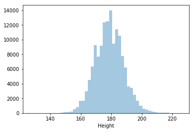

```python
#%matplotlib inline
#sns.stripplot(x=male_height_weight_age["Height"]) #stripplot good for inital but probably want to move on to  more advanced plots
sns.distplot(remove_null_height["Height"], kde= False )
```

```python
print(remove_null_height["Height"].mean())
print(remove_null_height["Height"].median())
```

```
178.85846329588276
179.0
```

##### *Explaination*:

First, I filtered the male_athletes dataframe to remove all null values for height, and assigned the result to the variable remove_null_height. Afterwards, I used the seaborn package to plot a distribution of heights. After reviewing the graph, you can see that the height for male athletes is pretty normally distributed. You can also confirm this by using the mean and median attribute to get the mean and median heights for male atheltes. The mean for height is 178.85846329588276 centimeters, and the median is 179.0 centimeters. Their is only a slight difference between the mean and median, which confirms the assumption that the heights of male atheltes are pretty normally distributed.

#### 5) Plot the distribution of male athletes Age

```python
remove_null_age= male_athletes[male_athletes["Age"].notnull()]
```

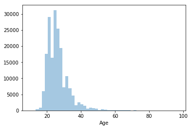

```python
sns.distplot(remove_null_age["Age"], kde= False )
```

```python
print(remove_null_age["Age"].mean())
print(remove_null_age["Age"].median())
```

```
26.277561532227104
25.0
```

##### *Explanation*:

First, I filtered the male_athletes dataframe to remove all null values for age, and assigned the result to the variable remove_null_age. Afterwards, I used the seaborn package to plot a distribution of age. After reviewing the graph, you can see that the age for male athletes is skewed right. You can also confirm this by using the mean and median attribute to get the mean and median age for male atheltes. The mean age is 26.277561532227104 and the median is 25.0. The mean is greater than the median which indicates that there are outliers in the data set. For the most part, people who participate in the Olympics are young, but there are some outliers that consist of older people that are bringing the average up.

#### 6) Plot the distribution of male athletes Weight

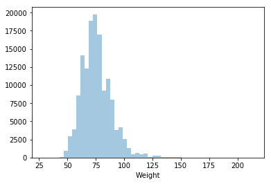

```python
remove_null_weight= male_athletes[male_athletes["Weight"].notnull()]
sns.distplot(remove_null_weight["Weight"], kde= False )
```

```python
remove_null_weight['Weight'].describe()
```

```
count    141470.000000
mean         75.743677
std          13.211610
min          28.000000
25%          67.000000
50%          74.000000
75%          83.000000
max         214.000000
Name: Weight, dtype: float64
```

```python
remove_null_weight[remove_null_weight["Weight"] ==214.000000]
```

| ID | Name | Sex | Age | Height | Weight | Team | NOC | Games | Year | Season | City | Sport | Event | Medal |
| --- | --- | --- | --- | --- | --- | --- | --- | --- | --- | --- | --- | --- | --- | --- |
| 12177 | Ricardo Blas, Jr. | M | 21.0 | 183.0 | 214.0 | Guam | GUM | 2008 Summer | 2008 | Summer | Beijing | Judo | Judo Men's Heavyweight | NaN |
| 12177 | Ricardo Blas, Jr. | M | 25.0 | 183.0 | 214.0 | Guam | GUM | 2012 Summer | 2012 | Summer | London | Judo | Judo Men's Heavyweight | NaN |

##### *Explanation*:

First, I filtered the male_athletes dataframe to remove all null values for weight, and assigned the result to the variable remove_null_weight. Afterwards, I used the seaborn package to plot a distribution of weight. After reviewing the graph, you can see that the weight for male athletes is skewed right. You can also confirm this by using the .describe() method on male atheltes. The mean weight is 75.743677 kilograms and the median weight is 74.000000 kilograms. The mean is greater than the median which indicates that their are outliers in the data set. Most people in the Olympics are relatively light weight, but there are some outliers in the dataset that weigh alot more. These heavy weight outliers may be people who play sports that have heavyweight events.

### Q3 Which female athlete competed in the most number of events? (5pt)

In which events did the athelete participate, and for what range of years? Which country did the athlete represent?

#### 1) Filter the olympic_games dataframe to retrieve only Female athletes

```python
female_athletes = olympic_games[olympic_games['Sex']== 'F']
```

##### Explanation:

In order to find the athlete that competed in the most amount of events I filtered the dataset to only show female atheletes. I assigned the resulting DataFrame to the variable female_athletes.

#### 2) Find which female athlete competed in the most number of events

```python
female_athletes_events = female_athletes \
    .groupby('Name')['Event'] \
    .count() \
    .sort_values(ascending = False) \
    .reset_index(name ='Number_of_Events')
```

##### Explanation:

My interepreation of this question is to look at the total times a female athlete has competed in an event regardless of whether they have competed in the event before. Therefore, I do not count the total number of unique events an athlete has participated in. I did this because the question does not specify unique events. Total events to me means all events competed in, whether or not the athlete has competed in the event before.

I grouped female_athletes by Name and used the .count method on the column 'Event'. This counts the total number of events the female participated in. Afterwards, for each unique name, I sorted the count of events from highest to lowest, and then I reset the index and named the new column Number_of_Events. When I reset the index I created a DataFrame (sorted from highest to lowest) with two columns: Name and Number_of_Events. The first column has the name of all the female athletes, and the second column has the number of events each athelete participated in.

I assigned the resulting DataFrame to the variable female_athletes_events.

```python
name_of_athlete = female_athletes_events["Name"].values[0]#get the name of the athlete
print(name_of_athlete)
```

```
Oksana Aleksandrovna Chusovitina
```

##### Explanation:

Since female_athletes_events has already been sorted from highest to lowest, I took the first row value in the column Name using the attribute .values and indexed at 0. I then extracted the Name of the athelete. I assigned the name of this athlete to the variable name_of_athlete. This is the name of the athlete who has competed in the greatest number of events. I found that the female athlete who has competed in the most number of events is Oksana Aleksandrovna Chusovitina.

#### 3) In which events did the athlete participate?

```python
female_athletes[female_athletes["Name"]==name_of_athlete]['Event'].unique()
```

```
array(["Gymnastics Women's Individual All-Around",
       "Gymnastics Women's Team All-Around",
       "Gymnastics Women's Floor Exercise",
       "Gymnastics Women's Horse Vault", "Gymnastics Women's Uneven Bars",
       "Gymnastics Women's Balance Beam"], dtype=object)
```

##### Explanation:

In order to find the events Oksana Aleksandrovna Chusovitina competed in, I filtered female_athletes where name is equal to Oksana Aleksandrovna Chusovitina. I then found all unique events that Oksana Aleksandrovna Chusovitina has participated in using the method .unique(). Below is the list the events Oksana Aleksandrovna Chusovitina competed in.

1. "Gymnastics Women's Individual All-Around",
2. "Gymnastics Women's Team All-Around",
3. "Gymnastics Women's Floor Exercise",
4. "Gymnastics Women's Horse Vault", "Gymnastics Women's Uneven Bars",
5. "Gymnastics Women's Balance Beam"

#### 4) For what range of years did Oksana Aleksandrovna Chusovitina participate in these events?

```python
female_athletes[female_athletes["Name"] == name_of_athlete]['Year'].unique()
```

```
array([1992, 1996, 2000, 2004, 2008, 2012, 2016])
```

##### Explanation:

In order to find the range of years Oksana Aleksandrovna Chusovitina competed in these events, I filtered female_athletes where name is equal to Oksana Aleksandrovna Chusovitina. I then found all unique years that Oksana Aleksandrovna Chusovitina participated in these events using the method .unique(). Below is the list of years Oksana Aleksandrovna Chusovitina competed in the events.

1. 1992
2. 1996
3. 2000
4. 2004
5. 2008
6. 2012
7. 2016

#### 5) Which country did the athlete represent?

```python
female_athletes[female_athletes["Name"]== name_of_athlete]['Team'].unique()
```

```
array(['Unified Team', 'Uzbekistan', 'Germany'], dtype=object)
```

##### Explanation:

In order to find the country Oksana Aleksandrovna Chusovitina represented, I filtered female_athletes where name is equal to Oksana Aleksandrovna Chusovitina. I then found all unique teams Oksana Aleksandrovna Chusovitina represented. I used team because the Team column is the country the athlete represents in the dataset. I found that Oksana Aleksandrovna Chusovitina represented three teams/countries over the course of her Olympic career. Below is a list of the countries she represented.

1. Unified Team: This was team name that represented the Soviet Union
2. Uzbekistan
3. Germany

### Q4 Which sport has the lowest median athlete age? (5pt)

To determine this, you might want to calculate and plot the median age for each sport. You may want to sort the axes appropriately for your analysis.

```python
median_age_sport = olympic_games \
    .groupby(['Sport'])["Age"] \
    .median() \
    .reset_index(name= 'Median_Age') \
    .sort_values(by = ["Median_Age"])
```

```python
median_age_sport.head()
```

|  | Sport | Median_Age |
| --- | --- | --- |
| 41 | Rhythmic Gymnastics | 18.0 |
| 54 | Swimming | 20.0 |
| 55 | Synchronized Swimming | 22.0 |
| 23 | Figure Skating | 22.0 |
| 20 | Diving | 22.0 |

##### Explanation:

In order to figure out the sport that has the lowest median athlete age I used DataFrame olympic_games and grouped by sport. I then took the median of the Age column for each sport, and reset the index and named the column Median_Age. Resetting the index of the DataFrame gives me a DataFrame with two columns: Sport and Median_Age. After resetting the index of the DataFrame I sorted the Median_Age column from lowest to highest. After doing this, I found that the sport with the lowest median athlete age is Rhythmic Gymnastics. The median athlete age for this sport 18. Below I plotted the distribution of Rhythmic Gymnastics athlete ages . The mean and median look to be around 18 from the chart, which confirms my finding that the median age for Rhythmic Gymnastics is 18.

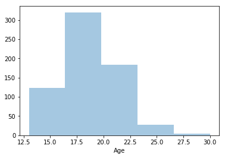

```python
sns.distplot(olympic_games[olympic_games["Sport"] =="Rhythmic Gymnastics"]["Age"] ,bins = 5, kde=False)
```

### Q5 Which countries have more female medalists than male medalists? (5pt)

#### 1) Create a new column called Team_Fix that has cleaned country names

```python
#using team need to create a nw column called team_Fix with fixed names
result = [team.split('-')[0].strip() for team in olympic_games["Team"]]
olympic_games["Team_Fix"]= np.array(result)
```

##### Explanation:

I am going to use the column Team to find the countries who have more female medalists than male medalists. The Team column has the name of the country that the athlete represented. After reviewing the Team column, I found that some countries have a dash and a number next to their name. I cleaned these country names so that the dash and number next to country names is deleted. I did this by doing list comprhension on the Team column. I split each country name on a dash and took the first value of the list (which will be the country name). I created a new column in olympic_games and assigned the cleaned country names to the column. This cleaned column is called Team_Fix. This new column will make it so countries will be more accurately grouped together later in the code.

#### 2) Filter olympic_games so that the rows that have null for the value in the column medal are removed

```python
athletes_with_medals = olympic_games[olympic_games["Medal"].notnull()]
```

##### Explanation:

In order to find the countries who have more female medalists than male medalists, I filtered out all rows that have null as their value in the column Medal. I did this because the rows that do not have information about medals are incomplete and should not be included in the final result. I assigned the filtered DataFrame to the variable athletes_with_medals.

#### 3) Find which countries have more female medalists than male medalists.

```python
athletes_country_sex_medals = athletes_with_medals \
    .groupby(["Team_Fix", 'Sex'])['Medal'] \
    .count() \
    .reset_index(name = 'Count')
#athletes_country_sex_medals
```

##### Explanation:

I grouped the athletes_with_medals by the columns Team_Fix and Sex. I then used the method .count() to count the total number of medals for each unique Sex and Team grouping. After this, I reset the index of the DataFrame and named the column with the total count of medals Count. I assigned the DataFrame to the variable athletes_country_sex_medals. This DataFrame has three columns: Team_Fix, Sex, and Count.

```python
females_versus_males = athletes_country_sex_medals \
    .pivot(index = 'Team_Fix', columns = 'Sex', values = 'Count') \
    .replace(np.nan, 0)
```

##### Explanation:

In this part of the code I used the method pivot on the DataFrame to re-arrange the organization of the DataFrame athletes_country_sex_medals. This allows me to filter the DataFrame so I am able to retrieve the information I want. I made the index of the DataFrame Team_Fix (which are the country names), and the columns are the Sex values (which are F and M). The values in the columns are the medal counts. I also replaced all null values in both the columns F and M with 0. I did this because if the medal count is null for a sex I am assuming that this is because there are 0 female or male participants for a given country. I assigned the result to the variable females_versus_males.

```python
#find the cities where there are more male medalist than female
# countries_more_male = females_versus_males \
#     .loc[females_versus_males['M'] > females_versus_males['F']] \
#     .index

# countries_same= females_versus_males \
#     .loc[females_versus_males['M'] == females_versus_males['F']] \
#     .index
#females_versus_males

countries_more_female = females_versus_males \
    .loc[females_versus_males['M'] < females_versus_males['F']] \
    .index

print(countries_more_female)
print(len(countries_more_female))
```

```
Index(['Bahrain', 'Belarus', 'Bonaparte', 'China', 'Clearwater', 'Costa Rica',
       'Digby', 'Elvis Va', 'Jamaica', 'Kosovo', 'Liechtenstein', 'Montenegro',
       'Mozambique', 'North Korea', 'Peru', 'Romania', 'Salinero', 'Satchmo',
       'Singapore', 'Sunrise', 'Ukraine', 'Zimbabwe'],
      dtype='object', name='Team_Fix')
22
```

##### Explanation:

Finally, I used loc on the females_versus_males DataFrame to filter properly. I found where there are a higher count of female medalists than male. Since Team_Fix is the index, I used the .index method to get a list of the countries with more female medalists than male. There are 22 countries who have more female medalists than male medalists. These countries include: 'Bahrain', 'Belarus', 'Bonaparte', 'China', 'Clearwater', 'Costa Rica','Digby', 'Elvis Va', 'Jamaica', 'Kosovo', 'Liechtenstein', 'Montenegro','Mozambique', 'North Korea', 'Peru', 'Romania', 'Salinero', 'Satchmo','Singapore', 'Sunrise', 'Ukraine', and 'Zimbabwe'. Below you can review the differences in medal count between males and females for these countries.

```python
females_versus_males \
    .loc[females_versus_males['M'] < females_versus_males['F']]
```

| Sex Team_Fix | F | M |
| --- | --- | --- |
| Bahrain | 3.0 | 0.0 |
| Belarus | 77.0 | 62.0 |
| Bonaparte | 1.0 | 0.0 |
| China | 654.0 | 335.0 |
| Clearwater | 1.0 | 0.0 |
| Costa Rica | 4.0 | 0.0 |
| Digby | 1.0 | 0.0 |
| Elvis Va | 1.0 | 0.0 |
| Jamaica | 86.0 | 71.0 |
| Kosovo | 1.0 | 0.0 |
| Liechtenstein | 5.0 | 4.0 |
| Montenegro | 14.0 | 0.0 |
| Mozambique | 2.0 | 0.0 |
| North Korea | 34.0 | 33.0 |
| Peru | 12.0 | 3.0 |
| Romania | 355.0 | 298.0 |
| Salinero | 1.0 | 0.0 |
| Satchmo | 1.0 | 0.0 |
| Singapore | 7.0 | 2.0 |
| Sunrise | 1.0 | 0.0 |
| Ukraine | 105.0 | 94.0 |
| Zimbabwe | 22.0 | 0.0 |

### Q6 Which country won the most medal points in the 2010 Winter Olympics? (5pt)

Rank each country by a score, where 3 points are assigned for a gold medal, 2 points for silver, and 1 point for bronze.

#### 1) Filter olympic_games so that the rows that have null for the value in the column medal are removed and make a copy of the DataFrame

```python
athletes_with_medals = olympic_games[olympic_games["Medal"].notnull()]
athletes_with_medals = athletes_with_medals.copy()
```

##### Explanation:

In order to find the country that won the most medal points in the 2010 Winter Olympics, I filtered out all rows that have null as their value in the column Medal. I did this because the rows that do not have information about medals are incomplete and should not be included in the final result. I assigned the filtered DataFrame to the variable athletes_with_medals. I made a copy of the DataFrame so that I am able to add a column to this DataFrame without getting an error (as talked about in office hours), and assigned the result to athletes_with_medals.

#### 2) Create a Score column with correct point assignment based on the type of medal the athlete earned

```python
athletes_with_medals["Score"] = athletes_with_medals["Medal"]
athletes_with_medals["Score"].replace(["Gold", "Silver", "Bronze"],
                                      [3, 2, 1],
                                      inplace = True)
```

##### Explanation:

I created a Score column in athletes_with_medals and originally assigned the values of this column to be the same values as the column Medal. After, I replaced the the values in the score column with 3, 2 , or 1. The scoring convention used is: 3 points are assigned for a gold medal, 2 points for silver, and 1 point for bronze. I used inplace = True so that the changes were made to the athletes_with_medals DataFrame.

#### 3) Find the country with the most medal points in the 2010 winter olympics

```python
athletes_country_medals = athletes_with_medals[(athletes_with_medals["Year"] == 2010) & (athletes_with_medals["Season"] == "Winter")]\
    .groupby(["Team_Fix"])["Score"] \
    .sum() \
    .reset_index(name = 'Total_Score') \
    .sort_values(by = "Total_Score", ascending = False)
athletes_country_medals
```

|  | Team_Fix | Total_Score |
| --- | --- | --- |
| 3 | Canada | 239 |
| 25 | United States | 184 |
| 10 | Germany | 108 |
| 17 | Norway | 85 |
| 1 | Austria | 57 |
| 8 | Finland | 48 |
| 23 | Sweden | 43 |
| 19 | Russia | 42 |
| 4 | China | 40 |
| 22 | South Korea | 40 |
| 24 | Switzerland | 24 |
| 9 | France | 24 |
| 16 | Netherlands | 20 |
| 6 | Czech Republic | 13 |
| 18 | Poland | 13 |
| 13 | Japan | 12 |
| 12 | Italy | 8 |
| 0 | Australia | 8 |
| 15 | Latvia | 6 |
| 20 | Slovakia | 6 |
| 2 | Belarus | 6 |
| 21 | Slovenia | 5 |
| 5 | Croatia | 5 |
| 11 | Great Britain | 3 |
| 14 | Kazakhstan | 2 |
| 7 | Estonia | 2 |

##### Explanation:

First, I filtered the DataFrame athletes_with_medals where year is equal to 2010 and the Season equals Winter. After, I grouped the filtered DataFrame using the Team_Fix column (this column was created and explained in Q5 part 1), and took the sum of the Score column using the .sum() method. Afterwards, I reset the index and named the sum of the score column Total_Score, and sorted the values in this column from largest to smallest. The result of this is a DataFrame with two columns: Team_Fix and Total_Score. I assigned the resulting DataFrame to the variable athletes_country_medals. I found that Canada is the country that has the most medal points in the 2010 Winter Olympics. Their medal points is 239.

### BONUS 5 pt: For each year in which games were held, what proportion of gold medals did the host country win?

You will need to combine multiple datasets to complete the analysis. We suggest using the following resource:

- https://en.wikipedia.org/wiki/List_of_Olympic_Games_host_cities (note: you can use the [read_html](https://pandas.pydata.org/pandas-docs/stable/generated/pandas.read_html.html) function to load the data into a DataFrame.

#### 1) Find online a list of IOC country codes and their associated country names

```python
noc_codes = pd.read_html(io='https://simple.wikipedia.org/wiki/List_of_IOC_country_codes', header=0)
noc_codes= pd.concat(noc_codes[1:25])
```

##### Explanation:

I used pd.read_html() to get the NOC codes and their country names. I then concatenated the dataframes with the tables I wanted (which are the indexes 1-24 in the list of dataframes retrieved). This new DataFrame is called noc_codes

#### 2) Create a column called Country in the olympic_games dataframe with the country names

```python
olympic_games["Country"] = olympic_games["NOC"]
olympic_games["Country"].replace(np.array(noc_codes["Code"]),
                                   np.array(noc_codes["Country"]),
                                   inplace = True)
```

##### Explanation:

First initalize a new column in the DataFrame olympic_games called Country. Initally, I assigned the values in this column to be the values in the column 'NOC'. Now, use .replace to replace the NOC codes in the column Country with the Country names from the dataframe noc_codes. Now, this creates a standardized list of country names that will be used to solve the answer to this question. There are still some codes that are not replaced (this is shown below). This is because the names of these countries are out-dated. For right now, I am not going to worry about fixing the country names because they may not be host countries.

```python
#shows the codes that were not replaced.
not_replaced = olympic_games[olympic_games["Country"].isin(olympic_games["NOC"])][["Team_Fix", "Country"]].drop_duplicates()
not_replaced_country_column = not_replaced["Country"].unique()
not_replaced_country_column
```

```
array(['URS', 'UAR', 'LIB', 'YAR', 'EUN', 'FRG', 'GDR', 'TCH', 'YMD',
       'ANZ', 'SCG', 'IOA', 'YUG', 'MAL', 'ROT', 'CRT', 'SAA', 'RHO',
       'BOH', 'WIF', 'NBO', 'VNM', 'UNK', 'NFL', 'KOS', 'SSD'],
      dtype=object)
```

#### 3) Use the link provided in the question, and a DataFrame that shows all host countries and years.

```python
olympic_locations_scraped = pd.read_html(io='https://en.wikipedia.org/wiki/List_of_Olympic_Games_host_cities', header = 0 )
```

```python
olympic_host_df = olympic_locations_scraped[1]
```

##### Explanation:

I used pd.read_html to scrape host countries and years. I assigned the list of dataframes to the variable olympic_locations_scraped. After reviewing the list of dataframes, I found that the DataFrame with the information I need. This DataFrame is the second element in the list olympic_locations_scraped. I took the index 1 of olympic_locations_scraped and assigned this DataFrame to the variable olympic_host_df.

#### 4) In olympic_games Country column replace Great Britian with United Kingdom

```python
#Noticed from lack year appareaing in final output that some places named differently
#found that 1908 "United Kindom" but in olympic_games United Kingdom is Called Great Britain
```

```python
#olympic_host_df[~olympic_host_df["Country"].isin(olympic_games["Country"].unique())]
```

```python
olympic_games["Country"].replace("Great Britain",
                                  "United Kingdom",
                                   inplace = True)
```

##### Explanation:

I am doing this because after reviewing the country names in olympic_host_df, and comparing them to the country names in olympic_games, I found that in olympic_host_df they use the value United Kingdom. In olympic_games they call United Kingdom Great Britian. In order to standardize naming, I decided to change the country names in olympic_games. I replaced the values that equal Great Britian in the column Country with the value United Kingdom.

#### 5) Get a total count of gold medals won for each country

```python
athletes_with_medals = olympic_games[olympic_games["Medal"].notnull()]
athletes_with_medals = athletes_with_medals.copy()
gold_medal_count_country = athletes_with_medals[athletes_with_medals["Medal"] == 'Gold'] \
    .groupby(["Country","Year"])["Medal"] \
    .count() \
    .reset_index(name= "Medal_Count")
#gold_medal_count_country
```

##### Explanation:

First, I filtered out all rows in the DataFrame olympic_games where values in the column Medal are equal to null. I assigned the value to the variable athletes_with_medals. I did this because the rows that do not have information about medals are incomplete and should not be included in the final result. Then I made a copy of the DataFrame athletes_with_medals. I did this because I will be filtering this DataFrame, and do not want to get any errors. I assigned the copy of this DataFrame to the same variable, athletes_with_medals. After, I filtered athletes_with_medals to only show where the value in the column Medal is equal to gold. I grouped by Country and Year, and used the method .count to count the number of gold medals for each unique country year combination. I then reset the index and named the new column Medal_Count. I assigned the resulting DataFrame to the variable gold_medal_count_country. This DataFrame, gold_medal_count_country, has 3 columns: Country, Year, and Medal_Count

#### 6) Get the total number of gold medals won for each year of the olympics

```python
gold_medal_year_total = gold_medal_count_country \
    .groupby(["Year"])["Medal_Count"] \
    .sum() \
    .reset_index(name = "Total_Gold_Medals")
```

##### Explanation:

In this part I am using the gold_medal_count_country DataFrame, created above, and I group the DataFrame by Year. After this I am using the .sum method to add up the total number of gold medals won for each year of Olympics. I then reset the index and named the new column Total_Gold_Medals. I assigned the resulting DataFrame to the variable gold_medal_year_total. This DataFrame, gold_medal_year_total, has 2 columns: Year and Total_Gold_Medals.

#### 7) Merge gold_medal_year_total and gold_medal_count_country with olympic_host_df

```python
medals_host_countries= olympic_host_df[["Country", "Year"]] \
    .set_index('Year') \
    .merge(gold_medal_count_country, on = ['Country',"Year"], right_index = True)

medals_host_countries_with_total = medals_host_countries.merge(gold_medal_year_total, how = "inner", on = "Year", right_index= True)
medals_host_countries_with_total = medals_host_countries_with_total.drop_duplicates()
```

##### Explanation:

From olympic_host_df only use the columns Country and Year and set the index to be year. After, merge the DataFrame with gold_medal_count_country on the columns Country and Year, and set right_index to be True. Assign the resulting DataFrame to the variable medals_host_countries. Now inner merge medals_host_countries with gold_medal_year_total on the column year, and set right_index to be true. Drop all duplicate rows that will result from this merge and assign the resulting DataFrame to the variable medals_host_countries_with_total.

#### 8) Now, find for each year in which games were held, what proportion of gold medals did the host country win

```python
medals_host_countries_with_total["Proportion_Gold"] = medals_host_countries_with_total["Medal_Count"]/ medals_host_countries_with_total["Total_Gold_Medals"]
```

##### Explanation:

```python
medals_host_countries_with_total
```

| Year | Country | Medal_Count | Total_Gold_Medals | Proportion_Gold |
| --- | --- | --- | --- | --- |
| 1896 | Greece | 10 | 62 | 0.161290 |
| 1900 | France | 52 | 201 | 0.258706 |
| 1904 | United States | 128 | 173 | 0.739884 |
| 1908 | United Kingdom | 147 | 294 | 0.500000 |
| 1912 | Sweden | 103 | 326 | 0.315951 |
| 1920 | Belgium | 57 | 493 | 0.115619 |
| 1924 | France | 37 | 332 | 0.111446 |
| 1928 | Switzerland | 16 | 275 | 0.058182 |
| 1928 | Netherlands | 20 | 275 | 0.072727 |
| 1932 | United States | 91 | 261 | 0.348659 |
| 1948 | Switzerland | 9 | 330 | 0.027273 |
| 1948 | United Kingdom | 7 | 330 | 0.021212 |
| 1952 | Norway | 12 | 351 | 0.034188 |
| 1952 | Finland | 14 | 351 | 0.039886 |
| 1956 | Italy | 28 | 353 | 0.079320 |
| 1960 | United States | 100 | 359 | 0.278552 |
| 1960 | Italy | 36 | 359 | 0.100279 |
| 1964 | Austria | 5 | 408 | 0.012255 |
| 1964 | Japan | 32 | 408 | 0.078431 |
| 1968 | France | 16 | 425 | 0.037647 |
| 1968 | Mexico | 3 | 425 | 0.007059 |
| 1972 | Japan | 30 | 474 | 0.063291 |
| 1976 | Austria | 2 | 508 | 0.003937 |
| 1976 | Canada | 1 | 508 | 0.001969 |
| 1980 | United States | 24 | 529 | 0.045369 |
| 1984 | United States | 190 | 571 | 0.332750 |
| 1988 | Canada | 4 | 607 | 0.006590 |
| 1988 | South Korea | 28 | 607 | 0.046129 |
| 1992 | France | 14 | 663 | 0.021116 |
| 1992 | Spain | 48 | 663 | 0.072398 |
| 1994 | Norway | 8 | 110 | 0.072727 |
| 1996 | United States | 159 | 608 | 0.261513 |
| 1998 | Japan | 8 | 145 | 0.055172 |
| 2000 | Australia | 60 | 663 | 0.090498 |
| 2002 | United States | 11 | 162 | 0.067901 |
| 2004 | Greece | 8 | 664 | 0.012048 |
| 2006 | Italy | 11 | 176 | 0.062500 |
| 2008 | China | 74 | 671 | 0.110283 |
| 2010 | Canada | 67 | 174 | 0.385057 |
| 2012 | United Kingdom | 48 | 632 | 0.075949 |
| 2014 | Russia | 33 | 202 | 0.163366 |
| 2014 | China | 3 | 202 | 0.014851 |
| 2016 | Brazil | 36 | 665 | 0.054135 |

```python
medals_host_countries_with_total.describe()
```

|  | Medal_Count | Total_Gold_Medals | Proportion_Gold |
| --- | --- | --- | --- |
| count | 43.000000 | 43.000000 | 43.000000 |
| mean | 41.627907 | 395.232558 | 0.126003 |
| std | 46.077070 | 180.625479 | 0.153022 |
| min | 1.000000 | 62.000000 | 0.001969 |
| 25% | 9.500000 | 268.000000 | 0.035918 |
| 50% | 28.000000 | 359.000000 | 0.072398 |
| 75% | 54.500000 | 550.000000 | 0.138454 |
| max | 190.000000 | 671.000000 | 0.739884 |

```python
medals_host_countries_with_total.max()
```

```
Country              United States
Medal_Count                    190
Total_Gold_Medals              671
Proportion_Gold           0.739884
dtype: object
```

```python
medals_host_countries_with_total[medals_host_countries_with_total["Country"] == 'United States']
```

| Year | Country | Medal_Count | Total_Gold_Medals | Proportion_Gold |
| --- | --- | --- | --- | --- |
| 1904 | United States | 128 | 173 | 0.739884 |
| 1932 | United States | 91 | 261 | 0.348659 |
| 1960 | United States | 100 | 359 | 0.278552 |
| 1980 | United States | 24 | 529 | 0.045369 |
| 1984 | United States | 190 | 571 | 0.332750 |
| 1996 | United States | 159 | 608 | 0.261513 |
| 2002 | United States | 11 | 162 | 0.067901 |

##### Explanation:

On average, a host country wins 0.126003, or 12.6003 percent, of all gold medals earned in the Olympics for that year. The median a host country wins is 0.072398, or 7.2398 percent, of all gold medals earned in the Olympucs for that year. The maximum proportion of gold medals a host country has won in the Olympics for a given year is 0.739884, or 73.9884 percent. This host country was the United States in 1904.

## Please submit your completed notebook in HTML format via Canvas.